# Customer Churn Problem

Zervaan Borok

2/20/2022

# Problem Background

Customer churn is a problem that all companies need to monitor, especially those that depend on subscription-based revenue streams. Customer churn refers to the situation when a customer ends their relationship with a company, and it’s a costly problem. Customers are the fuel that powers a business. Loss of customers impacts sales. Further, it’s much more difficult and costly to gain new customers than it is to retain existing customers. As a result, organizations need to focus on reducing customer churn.

The dataset used for this Keras tutorial is IBM Watson Telco Dataset. According to IBM, the business challenge is:

“A telecommunications company [Telco] is concerned about the number of customers leaving their landline business for cable competitors. They need to understand who is leaving. Imagine that you’re an analyst at this company and you have to find out who is leaving and why.”

We are going to use Keras library to to develop a sophisticated and highly accurate deep learning model in R. We walk you through the preprocessing steps, investing time into how to format the data for Keras.

# Part 1: Standard Dataframe & Model

```r
# Load libraries

library(keras) #modeling NN
library(tensorflow)
set_random_seed(42)
```

```
## Loaded Tensorflow version 2.7.0
```

```r
library(tidyverse) #for data manipulation
library(rsample) #for sampling
library(recipes) #for eficient preprocessing
library(yardstick) #Tidy methods for measuring model performance
library(corrr) #for Correlation Analysis
library(readr)
```

### Read Data

The dataset includes information about:

- Customers who left within the last month: The column is called Churn
- Services that each customer has signed up for: phone, multiple lines, internet, online security, online backup, device protection, tech support, and streaming TV and movies
- Customer account information: how long they’ve been a customer, contract, payment method, paperless billing, monthly charges, and total charges
- Demographic info about customers: gender, age range, and if they have partners and dependents

```r
#setwd("YOUR HOME DIRECTORY PATH")
churn_data_raw <- read_csv("C:\\Users\\zerva\\Documents\\AM11\\Telco-Customer-Churn.csv")
head(churn_data_raw)
```

```
## # A tibble: 6 x 21
##   customerID gender SeniorCitizen Partner Dependents tenure PhoneService
##   <chr>      <chr>          <dbl> <chr>   <chr>       <dbl> <chr>
## 1 7590-VHVEG Female             0 Yes     No              1 No
## 2 5575-GNVDE Male               0 No      No             34 Yes
## 3 3668-QPYBK Male               0 No      No              2 Yes
## 4 7795-CFOCW Male               0 No      No             45 No
## 5 9237-HQITU Female             0 No      No              2 Yes
## 6 9305-CDSKC Female             0 No      No              8 Yes
## # ... with 14 more variables: MultipleLines <chr>, InternetService <chr>,
## #   OnlineSecurity <chr>, OnlineBackup <chr>, DeviceProtection <chr>,
## #   TechSupport <chr>, StreamingTV <chr>, StreamingMovies <chr>,
## #   Contract <chr>, PaperlessBilling <chr>, PaymentMethod <chr>,
## #   MonthlyCharges <dbl>, TotalCharges <dbl>, Churn <chr>
```

```r
df <- churn_data_raw[sample(1:nrow(churn_data_raw)),]

df_1 <- df
df_2 <- df
df_3 <- df
```

### Prune and clean dataset

```r
churn_data_tbl <- churn_data_raw %>%
  select(-customerID) %>% # remove the customerID
  drop_na() %>%  # Drop rows that have NA(Not Available) Values
  select(Churn, everything())

head(churn_data_tbl) #dsiplay 6 first rows of the dataset.
```

```
## # A tibble: 6 x 20
##   Churn gender SeniorCitizen Partner Dependents tenure PhoneService
##   <chr> <chr>          <dbl> <chr>   <chr>       <dbl> <chr>
## 1 No    Female             0 Yes     No              1 No
## 2 No    Male               0 No      No             34 Yes
## 3 Yes   Male               0 No      No              2 Yes
## 4 No    Male               0 No      No             45 No
## 5 Yes   Female             0 No      No              2 Yes
## 6 Yes   Female             0 No      No              8 Yes
## # ... with 13 more variables: MultipleLines <chr>, InternetService <chr>,
## #   OnlineSecurity <chr>, OnlineBackup <chr>, DeviceProtection <chr>,
## #   TechSupport <chr>, StreamingTV <chr>, StreamingMovies <chr>,
## #   Contract <chr>, PaperlessBilling <chr>, PaymentMethod <chr>,
## #   MonthlyCharges <dbl>, TotalCharges <dbl>
```

### Split data

Split test/training sets using the rsample package

```r
set.seed(1000) #for reproducibility
train_test_split <- initial_split(churn_data_tbl, prop = 0.8)
train_tbl <- training(train_test_split)
test_tbl  <- testing(train_test_split)
cat("Dimensions of the training set is: ", dim(train_tbl), "\n")
```

```
## Dimensions of the training set is:  5625 20
```

```r
cat("Dimensions of the test set is: ", dim(test_tbl), "\n")
```

```
## Dimensions of the test set is:  1407 20
```

### Preprocess/Normalize the Data using the friendly “recipe”

1. we discretize the variable *tenure* into 6 categories
2. create the log transformation of *TotalCharges*
3. encode the categorical data into dummy variables
4. to mean-center the data
5. scale the data
6. prepare the recipe, i.e., estimate the required parameters from a training set that can later be applied to other data sets

```r
# Create recipe
rec_obj <- recipe(Churn ~ ., data = train_tbl) %>%
  step_discretize(tenure, options = list(cuts = 6)) %>%
  step_log(TotalCharges) %>%
  step_dummy(all_nominal(), -all_outcomes()) %>%
  step_center(all_predictors(), -all_outcomes()) %>%
  step_scale(all_predictors(), -all_outcomes()) %>%
  prep(data = train_tbl)

# Print the recipe object
rec_obj
```

```
## Data Recipe
##
## Inputs:
##
##       role #variables
##    outcome          1
##  predictor         19
##
## Training data contained 5625 data points and no missing data.
##
## Operations:
##
## Dummy variables from tenure [trained]
## Log transformation on TotalCharges [trained]
## Dummy variables from gender, Partner, Dependents, tenure, ... [trained]
## Centering for SeniorCitizen, MonthlyCharges, ... [trained]
## Scaling for SeniorCitizen, MonthlyCharges, ... [trained]
```

We can apply the “recipe” to any data set with the bake() function, and it processes the data following our recipe steps above. We apply to our training and testing data to convert from raw data to a machine learning dataset.

And finaly, we need to store the actual (truth) values as y_train_vec and y_test_vec, which are needed for training and testing our NN.

```r
# Creating the X and Y sets
x_train_tbl <- bake(rec_obj, new_data = train_tbl) %>% select(-Churn)
x_test_tbl  <- bake(rec_obj, new_data = test_tbl) %>% select(-Churn)
glimpse(x_train_tbl)
```

```
## Rows: 5,625
## Columns: 35
## $ SeniorCitizen                         <dbl> 2.2597752, -0.4424432, -0.442443~
## $ MonthlyCharges                        <dbl> 0.6894433, -1.5131770, 0.8600222~
## $ TotalCharges                          <dbl> 0.8761571, -0.9619181, 1.1644793~
## $ gender_Male                           <dbl> 0.9891258, -1.0108140, 0.9891258~
## $ Partner_Yes                           <dbl> -0.9651406, 1.0359342, -0.965140~
## $ Dependents_Yes                        <dbl> -0.6519643, 1.5335537, -0.651964~
## $ tenure_bin1                           <dbl> -0.4578648, -0.4578648, -0.45786~
## $ tenure_bin2                           <dbl> -0.4564439, 2.1904602, -0.456443~
## $ tenure_bin3                           <dbl> -0.4317701, -0.4317701, -0.43177~
## $ tenure_bin4                           <dbl> 2.2125451, -0.4518878, -0.451887~
## $ tenure_bin5                           <dbl> -0.4564439, -0.4564439, -0.45644~
## $ tenure_bin6                           <dbl> -0.4282878, -0.4282878, 2.334463~
## $ PhoneService_Yes                      <dbl> 0.3251784, 0.3251784, 0.3251784,~
```

[output cut: 22 more lines]

```r
y_train_vec <- ifelse(pull(train_tbl, Churn) == "Yes", 1, 0)
y_test_vec  <- ifelse(pull(test_tbl, Churn) == "Yes", 1, 0)
```

### Build the NN model

Finally, Deep Learning with Keras in R!

The first step is to initialize a sequential model with keras_model_sequential(), which is the beginning of our Keras model. The sequential model is composed of a linear stack (sequence) of layers.

*note*: The first layer needs to have the input_shape, that is the numeber of geatures that is getting fed by. In this case it is the number of columns in the x_train_tbl.

```r
# Building our Artificial Neural Network
model_keras <- keras_model_sequential()

model_keras %>%

  # First hidden layer
  layer_dense(
    units              = 16,
    kernel_initializer = "uniform",
    activation         = "relu",
    input_shape        = ncol(x_train_tbl)) %>%

  # Dropout to prevent overfitting
  layer_dropout(rate = 0.1) %>%

  # Second hidden layer
  layer_dense(
    units              = 16,
    kernel_initializer = "uniform",
    activation         = "relu") %>%

  # Dropout to prevent overfitting
  layer_dropout(rate = 0.1) %>%

  # Output layer
  layer_dense(
    units              = 1, #For multi-classification, the units should correspond to the number of classes
    kernel_initializer = "uniform",
    activation         = "sigmoid") %>%

  # Compile NN
  compile(
    optimizer = 'adam',
    loss      = 'binary_crossentropy',
    metrics   = c('accuracy')
  )

#display model architecture
model_keras
```

```
## Model
## Model: "sequential"
## ________________________________________________________________________________
##  Layer (type)                       Output Shape                    Param #
## ================================================================================
##  dense_2 (Dense)                    (None, 16)                      576
##
##  dropout_1 (Dropout)                (None, 16)                      0
##
##  dense_1 (Dense)                    (None, 16)                      272
##
##  dropout (Dropout)                  (None, 16)                      0
##
##  dense (Dense)                      (None, 1)                       17
##
## ================================================================================
## Total params: 865
## Trainable params: 865
## Non-trainable params: 0
## ________________________________________________________________________________
```

```r
# Train model
history <- fit(
  object           = model_keras,
  x                = as.matrix(x_train_tbl),
  y                = y_train_vec,
  batch_size       = 50,
  epochs           = 35,
  validation_split = 0.30 #to include 30% of the data for model validation, which prevents overfitting.
  ,verbose = 0
)
```

```r
# Print a summary of the training history
print(history)
```

```
##
## Final epoch (plot to see history):
##         loss: 0.4079
##     accuracy: 0.8105
##     val_loss: 0.4021
## val_accuracy: 0.8134
```

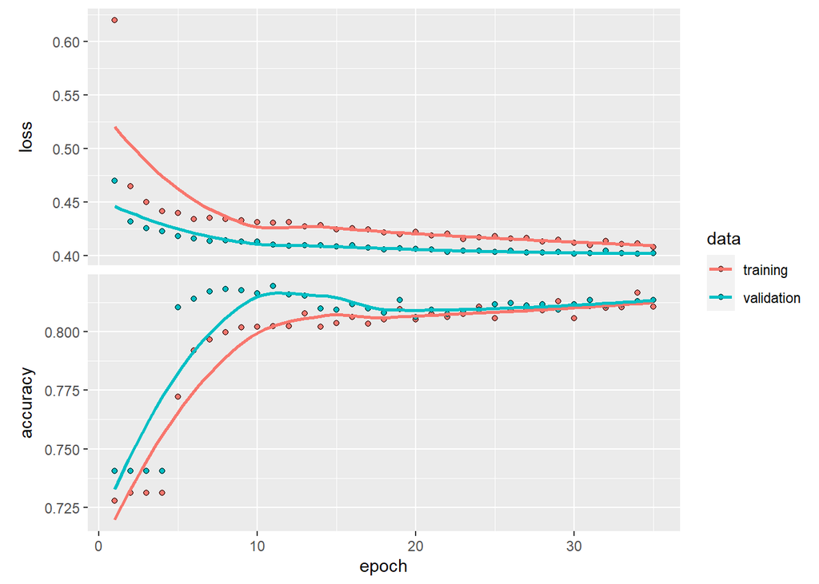

```r
# Plot the training/validation history of our Keras model
plot(history)
```

let’s make some predictions from our keras model on the test data set, which was unseen during modeling. You can predict *class* or *probability*

```r
# Predicted Class
yhat_keras_class_vec <- predict(object = model_keras, x = as.matrix(x_test_tbl)) %>% as.vector() %>% `>`(0.5)
# %>% k_cast("int32")


# Predicted Class Probability
yhat_keras_prob_vec  <- predict(object = model_keras, x = as.matrix(x_test_tbl)) %>%
    as.vector()
```

### Inspect Performance With Yardstick

```r
# Format test data and predictions for yardstick metrics
# estimates_keras_tbl <- tibble(
#   truth      = as.factor(y_test_vec) %>% fct_recode(yes = "1", no = "0"),
#   estimate   = as.factor(yhat_keras_class_vec) %>% fct_recode(yes = "1", no = "0"),
#   class_prob = yhat_keras_prob_vec
# )
estimates_keras_tbl <- tibble(
  truth      = as.factor(y_test_vec) %>% fct_recode(yes = "1", no = "0"),
  estimate   = as.factor(yhat_keras_class_vec) %>% fct_recode(yes = "TRUE", no = "FALSE"),
  class_prob = yhat_keras_prob_vec
)
options(yardstick.event_first = FALSE) # the default is to classify 0 as the positive class instead of 1
estimates_keras_tbl
```

```
## # A tibble: 1,407 x 3
##    truth estimate class_prob
##    <fct> <fct>         <dbl>
##  1 yes   yes          0.648
##  2 no    no           0.475
##  3 no    no           0.0124
##  4 no    no           0.0800
##  5 no    no           0.0223
##  6 yes   no           0.336
##  7 no    no           0.472
##  8 yes   yes          0.631
##  9 no    yes          0.513
## 10 no    no           0.156
## # ... with 1,397 more rows
```

### Confusion Table

```r
estimates_keras_tbl %>% conf_mat(truth, estimate)
```

```
##           Truth
## Prediction  no yes
##        no  913 175
##        yes 121 198
```

### Accuracy

```r
acc_0 <- estimates_keras_tbl %>% accuracy(truth, estimate)
```

### AUC

ROC Area Under the Curve (AUC) measurement

```r
roc_0 <- estimates_keras_tbl %>% roc_auc(truth, class_prob)
```

### Precision and Recall

Precision is when the model predicts “yes”, how often is it actually “yes”. Recall (also true positive rate) is when the actual value is “yes” how often is the model correct

```r
prec_0 <- estimates_keras_tbl %>% precision(truth, estimate)
rec_0 <- estimates_keras_tbl %>% recall(truth, estimate)
```

### F1 Score

weighted average between the precision and recal

```r
fmeas_0 <- estimates_keras_tbl %>% f_meas(truth, estimate)
```

```r
metrics_0 <- rbind(acc_0, roc_0, prec_0, rec_0, fmeas_0)
metrics_0
```

```
## # A tibble: 5 x 3
##   .metric   .estimator .estimate
##   <chr>     <chr>          <dbl>
## 1 accuracy  binary         0.790
## 2 roc_auc   binary         0.844
## 3 precision binary         0.621
## 4 recall    binary         0.531
## 5 f_meas    binary         0.572
```

# Part 2: Imputation

## Add in 35% missing values and drop NA rows

### Prune and clean dataset

```r
df_1 <- df_1 %>%
  select(-customerID) %>% # remove the customerID
  drop_na() %>%
  select(Churn, everything())

head(df_1) #dsiplay 6 first rows of the dataset.
```

```
## # A tibble: 6 x 20
##   Churn gender SeniorCitizen Partner Dependents tenure PhoneService
##   <chr> <chr>          <dbl> <chr>   <chr>       <dbl> <chr>
## 1 Yes   Male               0 Yes     Yes             7 No
## 2 No    Female             0 Yes     Yes            14 Yes
## 3 No    Female             0 Yes     No             72 Yes
## 4 Yes   Female             0 No      No              6 Yes
## 5 Yes   Male               0 Yes     Yes            25 Yes
## 6 Yes   Female             0 No      No              1 Yes
## # ... with 13 more variables: MultipleLines <chr>, InternetService <chr>,
## #   OnlineSecurity <chr>, OnlineBackup <chr>, DeviceProtection <chr>,
## #   TechSupport <chr>, StreamingTV <chr>, StreamingMovies <chr>,
## #   Contract <chr>, PaperlessBilling <chr>, PaymentMethod <chr>,
## #   MonthlyCharges <dbl>, TotalCharges <dbl>
```

```r
df_1$tenure[1:2461] <- NA
df_1$MonthlyCharges[1:2461] <- NA
df_1$TotalCharges[1:2461] <- NA
head(df_1)
```

```
## # A tibble: 6 x 20
##   Churn gender SeniorCitizen Partner Dependents tenure PhoneService
##   <chr> <chr>          <dbl> <chr>   <chr>       <dbl> <chr>
## 1 Yes   Male               0 Yes     Yes            NA No
## 2 No    Female             0 Yes     Yes            NA Yes
## 3 No    Female             0 Yes     No             NA Yes
## 4 Yes   Female             0 No      No             NA Yes
## 5 Yes   Male               0 Yes     Yes            NA Yes
## 6 Yes   Female             0 No      No             NA Yes
## # ... with 13 more variables: MultipleLines <chr>, InternetService <chr>,
## #   OnlineSecurity <chr>, OnlineBackup <chr>, DeviceProtection <chr>,
## #   TechSupport <chr>, StreamingTV <chr>, StreamingMovies <chr>,
## #   Contract <chr>, PaperlessBilling <chr>, PaymentMethod <chr>,
## #   MonthlyCharges <dbl>, TotalCharges <dbl>
```

```r
df_1 <- df_1 %>%
  drop_na() %>%
  select(Churn, everything())

head(df_1)
```

```
## # A tibble: 6 x 20
##   Churn gender SeniorCitizen Partner Dependents tenure PhoneService
##   <chr> <chr>          <dbl> <chr>   <chr>       <dbl> <chr>
## 1 No    Male               0 Yes     Yes            30 Yes
## 2 No    Male               0 Yes     No             72 Yes
## 3 No    Male               1 Yes     No             67 Yes
## 4 Yes   Female             1 Yes     No             28 Yes
## 5 No    Female             0 No      No             42 Yes
## 6 Yes   Male               1 Yes     No              6 Yes
## # ... with 13 more variables: MultipleLines <chr>, InternetService <chr>,
## #   OnlineSecurity <chr>, OnlineBackup <chr>, DeviceProtection <chr>,
## #   TechSupport <chr>, StreamingTV <chr>, StreamingMovies <chr>,
## #   Contract <chr>, PaperlessBilling <chr>, PaymentMethod <chr>,
## #   MonthlyCharges <dbl>, TotalCharges <dbl>
```

### Split data

Split test/training sets using the rsample package

```r
set.seed(1000) #for reproducibility
train_test_split_1 <- initial_split(df_1, prop = 0.8)
train_tbl_1 <- training(train_test_split_1)
test_tbl_1  <- testing(train_test_split_1)
cat("Dimensions of the training set is: ", dim(train_tbl_1), "\n")
```

```
## Dimensions of the training set is:  3656 20
```

```r
cat("Dimensions of the test set is: ", dim(test_tbl_1), "\n")
```

```
## Dimensions of the test set is:  915 20
```

```r
# Create recipe
rec_obj_1 <- recipe(Churn ~ ., data = train_tbl_1) %>%
  step_discretize(tenure, options = list(cuts = 6)) %>%
  step_log(TotalCharges) %>%
  step_dummy(all_nominal(), -all_outcomes()) %>%
  step_center(all_predictors(), -all_outcomes()) %>%
  step_scale(all_predictors(), -all_outcomes()) %>%
  prep(data = train_tbl_1)

# Print the recipe object
rec_obj_1
```

```
## Data Recipe
##
## Inputs:
##
##       role #variables
##    outcome          1
##  predictor         19
##
## Training data contained 3656 data points and no missing data.
##
## Operations:
##
## Dummy variables from tenure [trained]
## Log transformation on TotalCharges [trained]
## Dummy variables from gender, Partner, Dependents, tenure, ... [trained]
## Centering for SeniorCitizen, MonthlyCharges, ... [trained]
## Scaling for SeniorCitizen, MonthlyCharges, ... [trained]
```

We can apply the “recipe” to any data set with the bake() function, and it processes the data following our recipe steps above. We apply to our training and testing data to convert from raw data to a machine learning dataset.

And finaly, we need to store the actual (truth) values as y_train_vec and y_test_vec, which are needed for training and testing our NN.

```r
# Creating the X and Y sets
x_train_tbl_1 <- bake(rec_obj_1, new_data = train_tbl_1) %>% select(-Churn)
x_test_tbl_1  <- bake(rec_obj_1, new_data = test_tbl_1) %>% select(-Churn)
glimpse(x_train_tbl_1)
```

```
## Rows: 3,656
## Columns: 35
## $ SeniorCitizen                         <dbl> -0.4465652, -0.4465652, -0.44656~
## $ MonthlyCharges                        <dbl> -1.51213476, 0.16437555, 0.94741~
## $ TotalCharges                          <dbl> -0.57402197, 0.88573466, -0.6656~
## $ gender_Male                           <dbl> 0.9846636, 0.9846636, -1.0152975~
## $ Partner_Yes                           <dbl> -0.9601744, -0.9601744, -0.96017~
## $ Dependents_Yes                        <dbl> -0.6461343, -0.6461343, -0.64613~
## $ tenure_bin1                           <dbl> -0.4588447, -0.4588447, 2.178790~
## $ tenure_bin2                           <dbl> -0.4363939, -0.4363939, -0.43639~
## $ tenure_bin3                           <dbl> 2.195527, -0.455347, -0.455347, ~
## $ tenure_bin4                           <dbl> -0.4439196, -0.4439196, -0.44391~
## $ tenure_bin5                           <dbl> -0.4465652, 2.2387020, -0.446565~
## $ tenure_bin6                           <dbl> -0.4417108, -0.4417108, -0.44171~
## $ PhoneService_Yes                      <dbl> 0.3314615, 0.3314615, 0.3314615,~
```

[output cut: 22 more lines]

```r
y_train_vec_1 <- ifelse(pull(train_tbl_1, Churn) == "Yes", 1, 0)
y_test_vec_1  <- ifelse(pull(test_tbl_1, Churn) == "Yes", 1, 0)
```

### Build the NN model

Finally, Deep Learning with Keras in R!

The first step is to initialize a sequential model with keras_model_sequential(), which is the beginning of our Keras model. The sequential model is composed of a linear stack (sequence) of layers.

*note*: The first layer needs to have the input_shape, that is the numeber of geatures that is getting fed by. In this case it is the number of columns in the x_train_tbl.

```r
# Building our Artificial Neural Network
model_keras_1 <- keras_model_sequential()

model_keras_1 %>%

  # First hidden layer
  layer_dense(
    units              = 16,
    kernel_initializer = "uniform",
    activation         = "relu",
    input_shape        = ncol(x_train_tbl_1)) %>%

  # Dropout to prevent overfitting
  layer_dropout(rate = 0.1) %>%

  # Second hidden layer
  layer_dense(
    units              = 16,
    kernel_initializer = "uniform",
    activation         = "relu") %>%

  # Dropout to prevent overfitting
  layer_dropout(rate = 0.1) %>%

  # Output layer
  layer_dense(
    units              = 1, #For multi-classification, the units should correspond to the number of classes
    kernel_initializer = "uniform",
    activation         = "sigmoid") %>%

  # Compile NN
  compile(
    optimizer = 'adam',
    loss      = 'binary_crossentropy',
    metrics   = c('accuracy')
  )

#display model architecture
model_keras_1
```

```
## Model
## Model: "sequential_1"
## ________________________________________________________________________________
##  Layer (type)                       Output Shape                    Param #
## ================================================================================
##  dense_5 (Dense)                    (None, 16)                      576
##
##  dropout_3 (Dropout)                (None, 16)                      0
##
##  dense_4 (Dense)                    (None, 16)                      272
##
##  dropout_2 (Dropout)                (None, 16)                      0
##
##  dense_3 (Dense)                    (None, 1)                       17
##
## ================================================================================
## Total params: 865
## Trainable params: 865
## Non-trainable params: 0
## ________________________________________________________________________________
```

```r
# Train model
history_1 <- fit(
  object           = model_keras_1,
  x                = as.matrix(x_train_tbl_1),
  y                = y_train_vec_1,
  batch_size       = 50,
  epochs           = 35,
  validation_split = 0.30 #to include 30% of the data for model validation, which prevents overfitting.
  ,verbose = 0
)
```

```r
# Print a summary of the training history
print(history_1)
```

```
##
## Final epoch (plot to see history):
##         loss: 0.3951
##     accuracy: 0.8206
##     val_loss: 0.4368
## val_accuracy: 0.7967
```

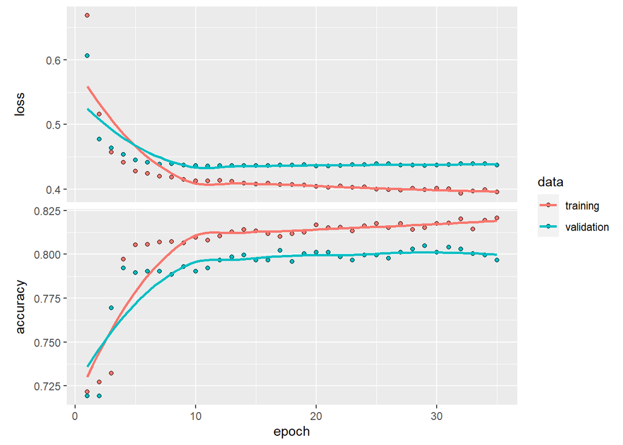

```r
# Plot the training/validation history of our Keras model
plot(history_1)
```

*Tip* Only use enough epochs to get a high validation accuracy. Once validation accuracy curve begins to flatten or decrease, it’s time to stop training.

let’s make some predictions from our keras model on the test data set, which was unseen during modeling. You can predict *class* or *probability*

```r
# Predicted Class
yhat_keras_class_vec_1 <- predict(object = model_keras_1, x = as.matrix(x_test_tbl_1)) %>% as.vector() %>% `>`(0.5)
# %>% k_cast("int32")


# Predicted Class Probability
yhat_keras_prob_vec_1  <- predict(object = model_keras_1, x = as.matrix(x_test_tbl_1)) %>%
    as.vector()
```

### Inspect Performance With Yardstick

```r
# Format test data and predictions for yardstick metrics
# estimates_keras_tbl <- tibble(
#   truth      = as.factor(y_test_vec) %>% fct_recode(yes = "1", no = "0"),
#   estimate   = as.factor(yhat_keras_class_vec) %>% fct_recode(yes = "1", no = "0"),
#   class_prob = yhat_keras_prob_vec
# )
estimates_keras_tbl_1 <- tibble(
  truth      = as.factor(y_test_vec_1) %>% fct_recode(yes = "1", no = "0"),
  estimate   = as.factor(yhat_keras_class_vec_1) %>% fct_recode(yes = "TRUE", no = "FALSE"),
  class_prob = yhat_keras_prob_vec_1
)
options(yardstick.event_first = FALSE) # the default is to classify 0 as the positive class instead of 1
estimates_keras_tbl_1
```

```
## # A tibble: 915 x 3
##    truth estimate class_prob
##    <fct> <fct>         <dbl>
##  1 yes   yes         0.719
##  2 no    no          0.173
##  3 no    no          0.201
##  4 no    no          0.319
##  5 no    no          0.00713
##  6 no    no          0.134
##  7 no    no          0.00798
##  8 no    yes         0.658
##  9 no    no          0.0250
## 10 no    no          0.0478
## # ... with 905 more rows
```

## Add in 35% missing values and replace with column means

### Prune and clean dataset

```r
df_2 <- df_2 %>%
  select(-customerID) %>% # remove the customerID
  drop_na() %>%
  select(Churn, everything())

head(df_2) #dsiplay 6 first rows of the dataset.
```

```
## # A tibble: 6 x 20
##   Churn gender SeniorCitizen Partner Dependents tenure PhoneService
##   <chr> <chr>          <dbl> <chr>   <chr>       <dbl> <chr>
## 1 Yes   Male               0 Yes     Yes             7 No
## 2 No    Female             0 Yes     Yes            14 Yes
## 3 No    Female             0 Yes     No             72 Yes
## 4 Yes   Female             0 No      No              6 Yes
## 5 Yes   Male               0 Yes     Yes            25 Yes
## 6 Yes   Female             0 No      No              1 Yes
## # ... with 13 more variables: MultipleLines <chr>, InternetService <chr>,
## #   OnlineSecurity <chr>, OnlineBackup <chr>, DeviceProtection <chr>,
## #   TechSupport <chr>, StreamingTV <chr>, StreamingMovies <chr>,
## #   Contract <chr>, PaperlessBilling <chr>, PaymentMethod <chr>,
## #   MonthlyCharges <dbl>, TotalCharges <dbl>
```

```r
df_2$tenure[1:2461] <- NA
df_2$MonthlyCharges[1:2461] <- NA
df_2$TotalCharges[1:2461] <- NA
head(df_2)
```

```
## # A tibble: 6 x 20
##   Churn gender SeniorCitizen Partner Dependents tenure PhoneService
##   <chr> <chr>          <dbl> <chr>   <chr>       <dbl> <chr>
## 1 Yes   Male               0 Yes     Yes            NA No
## 2 No    Female             0 Yes     Yes            NA Yes
## 3 No    Female             0 Yes     No             NA Yes
## 4 Yes   Female             0 No      No             NA Yes
## 5 Yes   Male               0 Yes     Yes            NA Yes
## 6 Yes   Female             0 No      No             NA Yes
## # ... with 13 more variables: MultipleLines <chr>, InternetService <chr>,
## #   OnlineSecurity <chr>, OnlineBackup <chr>, DeviceProtection <chr>,
## #   TechSupport <chr>, StreamingTV <chr>, StreamingMovies <chr>,
## #   Contract <chr>, PaperlessBilling <chr>, PaymentMethod <chr>,
## #   MonthlyCharges <dbl>, TotalCharges <dbl>
```

```r
is.nan.data.frame <- function(x)
do.call(cbind, lapply(x, is.na))

df_2$tenure[is.na(df_2$tenure)] <- mean(df_2$tenure[2462:7032])
df_2$MonthlyCharges[is.na(df_2$MonthlyCharges)] <- mean(df_2$MonthlyCharges[2462:7032])
df_2$TotalCharges[is.na(df_2$TotalCharges)] <- mean(df_2$TotalCharges[2462:7032])

head(df_2)
```

```
## # A tibble: 6 x 20
##   Churn gender SeniorCitizen Partner Dependents tenure PhoneService
##   <chr> <chr>          <dbl> <chr>   <chr>       <dbl> <chr>
## 1 Yes   Male               0 Yes     Yes          32.2 No
## 2 No    Female             0 Yes     Yes          32.2 Yes
## 3 No    Female             0 Yes     No           32.2 Yes
## 4 Yes   Female             0 No      No           32.2 Yes
## 5 Yes   Male               0 Yes     Yes          32.2 Yes
## 6 Yes   Female             0 No      No           32.2 Yes
## # ... with 13 more variables: MultipleLines <chr>, InternetService <chr>,
## #   OnlineSecurity <chr>, OnlineBackup <chr>, DeviceProtection <chr>,
## #   TechSupport <chr>, StreamingTV <chr>, StreamingMovies <chr>,
## #   Contract <chr>, PaperlessBilling <chr>, PaymentMethod <chr>,
## #   MonthlyCharges <dbl>, TotalCharges <dbl>
```

### Split data

Split test/training sets using the rsample package

```r
set.seed(1000) #for reproducibility
train_test_split_2 <- initial_split(df_2, prop = 0.8)
train_tbl_2 <- training(train_test_split_2)
test_tbl_2  <- testing(train_test_split_2)
cat("Dimensions of the training set is: ", dim(train_tbl_2), "\n")
```

```
## Dimensions of the training set is:  5625 20
```

```r
cat("Dimensions of the test set is: ", dim(test_tbl_2), "\n")
```

```
## Dimensions of the test set is:  1407 20
```

```r
# Create recipe
rec_obj_2 <- recipe(Churn ~ ., data = train_tbl_2) %>%
  step_discretize(tenure, options = list(cuts = 6)) %>%
  step_log(TotalCharges) %>%
  step_dummy(all_nominal(), -all_outcomes()) %>%
  step_center(all_predictors(), -all_outcomes()) %>%
  step_scale(all_predictors(), -all_outcomes()) %>%
  prep(data = train_tbl_2)
# Print the recipe object
rec_obj_2
```

```
## Data Recipe
##
## Inputs:
##
##       role #variables
##    outcome          1
##  predictor         19
##
## Training data contained 5625 data points and no missing data.
##
## Operations:
##
## Dummy variables from tenure [trained]
## Log transformation on TotalCharges [trained]
## Dummy variables from gender, Partner, Dependents, tenure, ... [trained]
## Centering for SeniorCitizen, MonthlyCharges, ... [trained]
## Scaling for SeniorCitizen, MonthlyCharges, ... [trained]
```

We can apply the “recipe” to any data set with the bake() function, and it processes the data following our recipe steps above. We apply to our training and testing data to convert from raw data to a machine learning dataset.

And finaly, we need to store the actual (truth) values as y_train_vec and y_test_vec, which are needed for training and testing our NN.

```r
# Creating the X and Y sets
x_train_tbl_2 <- bake(rec_obj_2, new_data = train_tbl_2) %>% select(-Churn)
x_test_tbl_2  <- bake(rec_obj_2, new_data = test_tbl_2) %>% select(-Churn)
glimpse(x_train_tbl_2)
```

```
## Rows: 5,625
## Columns: 34
## $ SeniorCitizen                         <dbl> -0.4387038, -0.4387038, -0.43870~
## $ MonthlyCharges                        <dbl> 0.872844943, 0.004272131, -1.838~
## $ TotalCharges                          <dbl> -0.368046937, 0.398139531, -0.33~
## $ gender_Male                           <dbl> -1.0075843, 0.9922963, 0.9922963~
## $ Partner_Yes                           <dbl> -0.9647971, -0.9647971, 1.036303~
## $ Dependents_Yes                        <dbl> -0.6522412, -0.6522412, 1.532902~
## $ tenure_bin1                           <dbl> -0.4626857, -0.4626857, -0.46268~
## $ tenure_bin2                           <dbl> 2.2941194, -0.4358196, -0.435819~
## $ tenure_bin3                           <dbl> -0.751091, 1.331160, -0.751091, ~
## $ tenure_bin4                           <dbl> -0.4009022, -0.4009022, 2.493930~
## $ tenure_bin5                           <dbl> -0.4441654, -0.4441654, -0.44416~
## $ PhoneService_Yes                      <dbl> 0.3301675, -3.0282272, 0.3301675~
## $ MultipleLines_No.phone.service        <dbl> -0.3301675, 3.0282272, -0.330167~
```

[output cut: 21 more lines]

```r
y_train_vec_2 <- ifelse(pull(train_tbl_2, Churn) == "Yes", 1, 0)
y_test_vec_2  <- ifelse(pull(test_tbl_2, Churn) == "Yes", 1, 0)
```

### Build the NN model

Finally, Deep Learning with Keras in R!

The first step is to initialize a sequential model with keras_model_sequential(), which is the beginning of our Keras model. The sequential model is composed of a linear stack (sequence) of layers.

*note*: The first layer needs to have the input_shape, that is the numeber of geatures that is getting fed by. In this case it is the number of columns in the x_train_tbl.

```r
# Building our Artificial Neural Network
model_keras_2 <- keras_model_sequential()

model_keras_2 %>%

  # First hidden layer
  layer_dense(
    units              = 16,
    kernel_initializer = "uniform",
    activation         = "relu",
    input_shape        = ncol(x_train_tbl_2)) %>%

  # Dropout to prevent overfitting
  layer_dropout(rate = 0.1) %>%

  # Second hidden layer
  layer_dense(
    units              = 16,
    kernel_initializer = "uniform",
    activation         = "relu") %>%

  # Dropout to prevent overfitting
  layer_dropout(rate = 0.1) %>%

  # Output layer
  layer_dense(
    units              = 1, #For multi-classification, the units should correspond to the number of classes
    kernel_initializer = "uniform",
    activation         = "sigmoid") %>%

  # Compile NN
  compile(
    optimizer = 'adam',
    loss      = 'binary_crossentropy',
    metrics   = c('accuracy')
  )

#display model architecture
model_keras_2
```

```
## Model
## Model: "sequential_2"
## ________________________________________________________________________________
##  Layer (type)                       Output Shape                    Param #
## ================================================================================
##  dense_8 (Dense)                    (None, 16)                      560
##
##  dropout_5 (Dropout)                (None, 16)                      0
##
##  dense_7 (Dense)                    (None, 16)                      272
##
##  dropout_4 (Dropout)                (None, 16)                      0
##
##  dense_6 (Dense)                    (None, 1)                       17
##
## ================================================================================
## Total params: 849
## Trainable params: 849
## Non-trainable params: 0
## ________________________________________________________________________________
```

```r
# Train model
history_2 <- fit(
  object           = model_keras_2,
  x                = as.matrix(x_train_tbl_2),
  y                = y_train_vec_2,
  batch_size       = 50,
  epochs           = 35,
  validation_split = 0.30 #to include 30% of the data for model validation, which prevents overfitting.
  ,verbose = 0
)
```

```r
# Print a summary of the training history
print(history_2)
```

```
##
## Final epoch (plot to see history):
##         loss: 0.4034
##     accuracy: 0.8148
##     val_loss: 0.4144
## val_accuracy: 0.8027
```

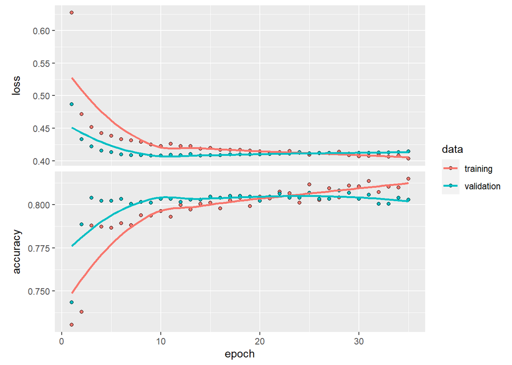

```r
# Plot the training/validation history of our Keras model
plot(history_2)
```

*Tip* Only use enough epochs to get a high validation accuracy. Once validation accuracy curve begins to flatten or decrease, it’s time to stop training.

let’s make some predictions from our keras model on the test data set, which was unseen during modeling. You can predict *class* or *probability*

```r
# Predicted Class
yhat_keras_class_vec_2 <- predict(object = model_keras_2, x = as.matrix(x_test_tbl_2)) %>% as.vector() %>% `>`(0.5)
# %>% k_cast("int32")


# Predicted Class Probability
yhat_keras_prob_vec_2  <- predict(object = model_keras_2, x = as.matrix(x_test_tbl_2)) %>%
    as.vector()
```

### Inspect Performance With Yardstick

```r
# Format test data and predictions for yardstick metrics
# estimates_keras_tbl <- tibble(
#   truth      = as.factor(y_test_vec) %>% fct_recode(yes = "1", no = "0"),
#   estimate   = as.factor(yhat_keras_class_vec) %>% fct_recode(yes = "1", no = "0"),
#   class_prob = yhat_keras_prob_vec
# )
estimates_keras_tbl_2 <- tibble(
  truth      = as.factor(y_test_vec_2) %>% fct_recode(yes = "1", no = "0"),
  estimate   = as.factor(yhat_keras_class_vec_2) %>% fct_recode(yes = "TRUE", no = "FALSE"),
  class_prob = yhat_keras_prob_vec_2
)
options(yardstick.event_first = FALSE) # the default is to classify 0 as the positive class instead of 1
estimates_keras_tbl_2
```

```
## # A tibble: 1,407 x 3
##    truth estimate class_prob
##    <fct> <fct>         <dbl>
##  1 yes   yes         0.531
##  2 no    no          0.0359
##  3 no    no          0.00318
##  4 no    no          0.425
##  5 no    no          0.00304
##  6 yes   no          0.446
##  7 no    no          0.0108
##  8 no    no          0.0194
##  9 yes   yes         0.634
## 10 no    no          0.200
## # ... with 1,397 more rows
```

## Add in 35% missing values and replace with column medians

### Prune and clean dataset

```r
df_3 <- df_3 %>%
  select(-customerID) %>% # remove the customerID
  drop_na() %>%
  select(Churn, everything())

head(df_3) #dsiplay 6 first rows of the dataset.
```

```
## # A tibble: 6 x 20
##   Churn gender SeniorCitizen Partner Dependents tenure PhoneService
##   <chr> <chr>          <dbl> <chr>   <chr>       <dbl> <chr>
## 1 Yes   Male               0 Yes     Yes             7 No
## 2 No    Female             0 Yes     Yes            14 Yes
## 3 No    Female             0 Yes     No             72 Yes
## 4 Yes   Female             0 No      No              6 Yes
## 5 Yes   Male               0 Yes     Yes            25 Yes
## 6 Yes   Female             0 No      No              1 Yes
## # ... with 13 more variables: MultipleLines <chr>, InternetService <chr>,
## #   OnlineSecurity <chr>, OnlineBackup <chr>, DeviceProtection <chr>,
## #   TechSupport <chr>, StreamingTV <chr>, StreamingMovies <chr>,
## #   Contract <chr>, PaperlessBilling <chr>, PaymentMethod <chr>,
## #   MonthlyCharges <dbl>, TotalCharges <dbl>
```

```r
df_3$tenure[1:2461] <- NA
df_3$MonthlyCharges[1:2461] <- NA
df_3$TotalCharges[1:2461] <- NA
head(df_3)
```

```
## # A tibble: 6 x 20
##   Churn gender SeniorCitizen Partner Dependents tenure PhoneService
##   <chr> <chr>          <dbl> <chr>   <chr>       <dbl> <chr>
## 1 Yes   Male               0 Yes     Yes            NA No
## 2 No    Female             0 Yes     Yes            NA Yes
## 3 No    Female             0 Yes     No             NA Yes
## 4 Yes   Female             0 No      No             NA Yes
## 5 Yes   Male               0 Yes     Yes            NA Yes
## 6 Yes   Female             0 No      No             NA Yes
## # ... with 13 more variables: MultipleLines <chr>, InternetService <chr>,
## #   OnlineSecurity <chr>, OnlineBackup <chr>, DeviceProtection <chr>,
## #   TechSupport <chr>, StreamingTV <chr>, StreamingMovies <chr>,
## #   Contract <chr>, PaperlessBilling <chr>, PaymentMethod <chr>,
## #   MonthlyCharges <dbl>, TotalCharges <dbl>
```

```r
is.nan.data.frame <- function(x)
do.call(cbind, lapply(x, is.na))

df_3$tenure[is.na(df_3$tenure)] <- median(df_3$tenure[2462:7032])
df_3$MonthlyCharges[is.na(df_3$MonthlyCharges)] <- median(df_3$MonthlyCharges[2462:7032])
df_3$TotalCharges[is.na(df_3$TotalCharges)] <- median(df_3$TotalCharges[2462:7032])

head(df_3)
```

```
## # A tibble: 6 x 20
##   Churn gender SeniorCitizen Partner Dependents tenure PhoneService
##   <chr> <chr>          <dbl> <chr>   <chr>       <dbl> <chr>
## 1 Yes   Male               0 Yes     Yes            29 No
## 2 No    Female             0 Yes     Yes            29 Yes
## 3 No    Female             0 Yes     No             29 Yes
## 4 Yes   Female             0 No      No             29 Yes
## 5 Yes   Male               0 Yes     Yes            29 Yes
## 6 Yes   Female             0 No      No             29 Yes
## # ... with 13 more variables: MultipleLines <chr>, InternetService <chr>,
## #   OnlineSecurity <chr>, OnlineBackup <chr>, DeviceProtection <chr>,
## #   TechSupport <chr>, StreamingTV <chr>, StreamingMovies <chr>,
## #   Contract <chr>, PaperlessBilling <chr>, PaymentMethod <chr>,
## #   MonthlyCharges <dbl>, TotalCharges <dbl>
```

### Split data

Split test/training sets using the rsample package

```r
set.seed(1000) #for reproducibility
train_test_split_3 <- initial_split(df_3, prop = 0.8)
train_tbl_3 <- training(train_test_split_3)
test_tbl_3  <- testing(train_test_split_3)
cat("Dimensions of the training set is: ", dim(train_tbl_3), "\n")
```

```
## Dimensions of the training set is:  5625 20
```

```r
cat("Dimensions of the test set is: ", dim(test_tbl_3), "\n")
```

```
## Dimensions of the test set is:  1407 20
```

### Preprocess/Normalize the Data using the friendly “recipe”

```r
# Create recipe
rec_obj_3 <- recipe(Churn ~ ., data = train_tbl_3) %>%
  step_discretize(tenure, options = list(cuts = 6)) %>%
  step_log(TotalCharges) %>%
  step_dummy(all_nominal(), -all_outcomes()) %>%
  step_center(all_predictors(), -all_outcomes()) %>%
  step_scale(all_predictors(), -all_outcomes()) %>%
  prep(data = train_tbl_3)
# Print the recipe object
rec_obj_3
```

```
## Data Recipe
##
## Inputs:
##
##       role #variables
##    outcome          1
##  predictor         19
##
## Training data contained 5625 data points and no missing data.
##
## Operations:
##
## Dummy variables from tenure [trained]
## Log transformation on TotalCharges [trained]
## Dummy variables from gender, Partner, Dependents, tenure, ... [trained]
## Centering for SeniorCitizen, MonthlyCharges, ... [trained]
## Scaling for SeniorCitizen, MonthlyCharges, ... [trained]
```

We can apply the “recipe” to any data set with the bake() function, and it processes the data following our recipe steps above. We apply to our training and testing data to convert from raw data to a machine learning dataset.

And finaly, we need to store the actual (truth) values as y_train_vec and y_test_vec, which are needed for training and testing our NN.

```r
# Creating the X and Y sets
x_train_tbl_3 <- bake(rec_obj_3, new_data = train_tbl_3) %>% select(-Churn)
x_test_tbl_3  <- bake(rec_obj_3, new_data = test_tbl_3) %>% select(-Churn)
glimpse(x_train_tbl_3)
```

```
## Rows: 5,625
## Columns: 33
## $ SeniorCitizen                         <dbl> -0.4387038, -0.4387038, -0.43870~
## $ MonthlyCharges                        <dbl> 0.7953093, 0.1451314, -1.9014980~
## $ TotalCharges                          <dbl> -0.25214934, 0.16230405, -0.2205~
## $ gender_Male                           <dbl> -1.0075843, 0.9922963, 0.9922963~
## $ Partner_Yes                           <dbl> -0.9647971, -0.9647971, 1.036303~
## $ Dependents_Yes                        <dbl> -0.6522412, -0.6522412, 1.532902~
## $ tenure_bin1                           <dbl> -0.4626857, -0.4626857, -0.46268~
## $ tenure_bin2                           <dbl> 0.999378, 0.999378, -1.000445, 0~
## $ tenure_bin3                           <dbl> -0.4340858, -0.4340858, 2.303282~
## $ tenure_bin4                           <dbl> -0.4441654, -0.4441654, -0.44416~
## $ PhoneService_Yes                      <dbl> 0.3301675, -3.0282272, 0.3301675~
## $ MultipleLines_No.phone.service        <dbl> -0.3301675, 3.0282272, -0.330167~
## $ MultipleLines_Yes                     <dbl> 1.1795483, -0.8476314, -0.847631~
```

[output cut: 20 more lines]

```r
y_train_vec_3 <- ifelse(pull(train_tbl_3, Churn) == "Yes", 1, 0)
y_test_vec_3  <- ifelse(pull(test_tbl_3, Churn) == "Yes", 1, 0)
```

### Build the NN model

Finally, Deep Learning with Keras in R!

The first step is to initialize a sequential model with keras_model_sequential(), which is the beginning of our Keras model. The sequential model is composed of a linear stack (sequence) of layers.

*note*: The first layer needs to have the input_shape, that is the numeber of geatures that is getting fed by. In this case it is the number of columns in the x_train_tbl.

```r
# Building our Artificial Neural Network
model_keras_3 <- keras_model_sequential()

model_keras_3 %>%

  # First hidden layer
  layer_dense(
    units              = 16,
    kernel_initializer = "uniform",
    activation         = "relu",
    input_shape        = ncol(x_train_tbl_3)) %>%

  # Dropout to prevent overfitting
  layer_dropout(rate = 0.1) %>%

  # Second hidden layer
  layer_dense(
    units              = 16,
    kernel_initializer = "uniform",
    activation         = "relu") %>%

  # Dropout to prevent overfitting
  layer_dropout(rate = 0.1) %>%

  # Output layer
  layer_dense(
    units              = 1, #For multi-classification, the units should correspond to the number of classes
    kernel_initializer = "uniform",
    activation         = "sigmoid") %>%

  # Compile NN
  compile(
    optimizer = 'adam',
    loss      = 'binary_crossentropy',
    metrics   = c('accuracy')
  )

#display model architecture
model_keras_3
```

```
## Model
## Model: "sequential_3"
## ________________________________________________________________________________
##  Layer (type)                       Output Shape                    Param #
## ================================================================================
##  dense_11 (Dense)                   (None, 16)                      544
##
##  dropout_7 (Dropout)                (None, 16)                      0
##
##  dense_10 (Dense)                   (None, 16)                      272
##
##  dropout_6 (Dropout)                (None, 16)                      0
##
##  dense_9 (Dense)                    (None, 1)                       17
##
## ================================================================================
## Total params: 833
## Trainable params: 833
## Non-trainable params: 0
## ________________________________________________________________________________
```

```r
# Train model
history_3 <- fit(
  object           = model_keras_3,
  x                = as.matrix(x_train_tbl_3),
  y                = y_train_vec_3,
  batch_size       = 50,
  epochs           = 35,
  validation_split = 0.30 #to include 30% of the data for model validation, which prevents overfitting.
  ,verbose = 0
)
```

```r
# Print a summary of the training history
print(history_3)
```

```
##
## Final epoch (plot to see history):
##         loss: 0.4076
##     accuracy: 0.8108
##     val_loss: 0.4136
## val_accuracy: 0.8075
```

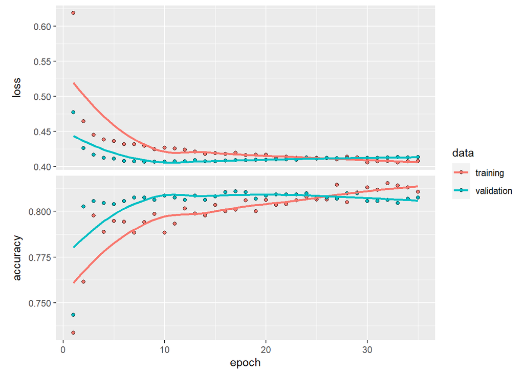

```r
# Plot the training/validation history of our Keras model
plot(history_3)
```

*Tip* Only use enough epochs to get a high validation accuracy. Once validation accuracy curve begins to flatten or decrease, it’s time to stop training.

let’s make some predictions from our keras model on the test data set, which was unseen during modeling. You can predict *class* or *probability*

```r
# Predicted Class
yhat_keras_class_vec_3 <- predict(object = model_keras_3, x = as.matrix(x_test_tbl_3)) %>% as.vector() %>% `>`(0.5)
# %>% k_cast("int32")


# Predicted Class Probability
yhat_keras_prob_vec_3  <- predict(object = model_keras_3, x = as.matrix(x_test_tbl_3)) %>%
    as.vector()
```

### Inspect Performance With Yardstick

```r
# Format test data and predictions for yardstick metrics
# estimates_keras_tbl <- tibble(
#   truth      = as.factor(y_test_vec) %>% fct_recode(yes = "1", no = "0"),
#   estimate   = as.factor(yhat_keras_class_vec) %>% fct_recode(yes = "1", no = "0"),
#   class_prob = yhat_keras_prob_vec
# )
estimates_keras_tbl_3 <- tibble(
  truth      = as.factor(y_test_vec_3) %>% fct_recode(yes = "1", no = "0"),
  estimate   = as.factor(yhat_keras_class_vec_3) %>% fct_recode(yes = "TRUE", no = "FALSE"),
  class_prob = yhat_keras_prob_vec_3
)
options(yardstick.event_first = FALSE) # the default is to classify 0 as the positive class instead of 1
estimates_keras_tbl_3
```

```
## # A tibble: 1,407 x 3
##    truth estimate class_prob
##    <fct> <fct>         <dbl>
##  1 yes   no          0.464
##  2 no    no          0.0237
##  3 no    no          0.00233
##  4 no    no          0.388
##  5 no    no          0.00609
##  6 yes   no          0.436
##  7 no    no          0.0105
##  8 no    no          0.0169
##  9 yes   yes         0.607
## 10 no    no          0.328
## # ... with 1,397 more rows
```

### Confusion Table

```r
estimates_keras_tbl_1 %>% conf_mat(truth, estimate)
```

```
##           Truth
## Prediction  no yes
##        no  584 109
##        yes  76 146
```

### Accuracy

```r
acc_1 <- estimates_keras_tbl_1 %>% accuracy(truth, estimate)
```

### AUC

ROC Area Under the Curve (AUC) measurement

```r
roc_1 <- estimates_keras_tbl_1 %>% roc_auc(truth, class_prob)
```

### Precision and Recall

Precision is when the model predicts “yes”, how often is it actually “yes”. Recall (also true positive rate) is when the actual value is “yes” how often is the model correct

```r
prec_1 <- estimates_keras_tbl_1 %>% precision(truth, estimate)
rec_1 <- estimates_keras_tbl_1 %>% recall(truth, estimate)
```

### F1 Score

weighted average between the precision and recal

```r
fmeas_1 <- estimates_keras_tbl_1 %>% f_meas(truth, estimate)
```

```r
metrics_1 <- rbind(acc_1, roc_1, prec_1, rec_1, fmeas_1)
metrics_1 <- metrics_1 %>%
  add_column(Model = c('35% Removed', '35% Removed', '35% Removed', '35% Removed', '35% Removed'), .before=".metric")
metrics_1
```

```
## # A tibble: 5 x 4
##   Model       .metric   .estimator .estimate
##   <chr>       <chr>     <chr>          <dbl>
## 1 35% Removed accuracy  binary         0.798
## 2 35% Removed roc_auc   binary         0.844
## 3 35% Removed precision binary         0.658
## 4 35% Removed recall    binary         0.573
## 5 35% Removed f_meas    binary         0.612
```

### Confusion Table

```r
estimates_keras_tbl_2 %>% conf_mat(truth, estimate)
```

```
##           Truth
## Prediction  no yes
##        no  906 185
##        yes 110 206
```

### Accuracy

```r
acc_2 <- estimates_keras_tbl_2 %>% accuracy(truth, estimate)
```

### AUC

ROC Area Under the Curve (AUC) measurement

```r
roc_2 <- estimates_keras_tbl_2 %>% roc_auc(truth, class_prob)
```

### Precision and Recall

Precision is when the model predicts “yes”, how often is it actually “yes”. Recall (also true positive rate) is when the actual value is “yes” how often is the model correct

```r
prec_2 <- estimates_keras_tbl_2 %>% precision(truth, estimate)
rec_2 <- estimates_keras_tbl_2 %>% recall(truth, estimate)
```

### F1 Score

weighted average between the precision and recal

```r
fmeas_2 <- estimates_keras_tbl_2 %>% f_meas(truth, estimate)
```

```r
metrics_2 <- rbind(acc_2, roc_2, prec_2, rec_2, fmeas_2)
metrics_2 <- metrics_2 %>%
  add_column(Model = c('35% Mean Imputation', '35% Mean Imputation', '35% Mean Imputation', '35% Mean Imputation', '35% Mean Imputation'), .before=".metric")
metrics_2
```

```
## # A tibble: 5 x 4
##   Model               .metric   .estimator .estimate
##   <chr>               <chr>     <chr>          <dbl>
## 1 35% Mean Imputation accuracy  binary         0.790
## 2 35% Mean Imputation roc_auc   binary         0.830
## 3 35% Mean Imputation precision binary         0.652
## 4 35% Mean Imputation recall    binary         0.527
## 5 35% Mean Imputation f_meas    binary         0.583
```

### Confusion Table

```r
estimates_keras_tbl_3 %>% conf_mat(truth, estimate)
```

```
##           Truth
## Prediction  no yes
##        no  900 187
##        yes 116 204
```

### Accuracy

```r
acc_3 <- estimates_keras_tbl_3 %>% accuracy(truth, estimate)
```

### AUC

ROC Area Under the Curve (AUC) measurement

```r
roc_3 <- estimates_keras_tbl_3 %>% roc_auc(truth, class_prob)
```

### Precision and Recall

Precision is when the model predicts “yes”, how often is it actually “yes”. Recall (also true positive rate) is when the actual value is “yes” how often is the model correct

```r
prec_3 <- estimates_keras_tbl_3 %>% precision(truth, estimate)
rec_3 <- estimates_keras_tbl_3 %>% recall(truth, estimate)
```

### F1 Score

weighted average between the precision and recal

```r
fmeas_3 <- estimates_keras_tbl_3 %>% f_meas(truth, estimate)
```

```r
metrics_3 <- rbind(acc_3, roc_3, prec_3, rec_3, fmeas_3)
metrics_3 <- metrics_3 %>%
  add_column(Model = c('35% Median Imputation', '35% Median Imputation', '35% Median Imputation', '35% Median Imputation', '35% Median Imputation'), .before=".metric")
metrics_3
```

```
## # A tibble: 5 x 4
##   Model                 .metric   .estimator .estimate
##   <chr>                 <chr>     <chr>          <dbl>
## 1 35% Median Imputation accuracy  binary         0.785
## 2 35% Median Imputation roc_auc   binary         0.829
## 3 35% Median Imputation precision binary         0.638
## 4 35% Median Imputation recall    binary         0.522
## 5 35% Median Imputation f_meas    binary         0.574
```

```r
model_metrics_combined <- rbind(metrics_1, metrics_2, metrics_3)
names(model_metrics_combined)[names(model_metrics_combined) == ".metric"] <- "Metric"
names(model_metrics_combined)[names(model_metrics_combined) == ".estimator"] <- "Estimator"
names(model_metrics_combined)[names(model_metrics_combined) == ".estimate"] <- "Estimate"

model_metrics_combined <- model_metrics_combined %>%
                            add_row(Model = NA, Metric = NA, Estimator = NA, Estimate = NA, .before = 6) %>%
                            add_row(Model = NA, Metric = NA, Estimator = NA, Estimate = NA, .before = 12)

model_metrics_combined$Model[is.na(model_metrics_combined$Model)] <- "--"
model_metrics_combined$Metric[is.na(model_metrics_combined$Metric)] <- "--"
model_metrics_combined$Estimator[is.na(model_metrics_combined$Estimator)] <- "--"
model_metrics_combined$Estimate[is.na(model_metrics_combined$Estimate)] <- "--"

model_metrics_combined
```

```
## # A tibble: 17 x 4
##    Model                 Metric    Estimator Estimate
##    <chr>                 <chr>     <chr>     <chr>
##  1 35% Removed           accuracy  binary    0.797814207650273
##  2 35% Removed           roc_auc   binary    0.844263220439691
##  3 35% Removed           precision binary    0.657657657657658
##  4 35% Removed           recall    binary    0.572549019607843
##  5 35% Removed           f_meas    binary    0.612159329140461
##  6 --                    --        --        --
##  7 35% Mean Imputation   accuracy  binary    0.790334044065387
##  8 35% Mean Imputation   roc_auc   binary    0.829501631189963
##  9 35% Mean Imputation   precision binary    0.651898734177215
## 10 35% Mean Imputation   recall    binary    0.526854219948849
## 11 35% Mean Imputation   f_meas    binary    0.582743988684583
## 12 --                    --        --        --
## 13 35% Median Imputation accuracy  binary    0.784648187633262
## 14 35% Median Imputation roc_auc   binary    0.828663380792235
## 15 35% Median Imputation precision binary    0.6375
## 16 35% Median Imputation recall    binary    0.521739130434783
## 17 35% Median Imputation f_meas    binary    0.573839662447257
```

# Hyperparameter Tuning

```r
FLAGS <- flags(
  flag_numeric('dropout1', 0.1),
  flag_integer('neurons1', 16),
  flag_numeric('dropout2', 0.1),
  flag_integer('neurons2', 16)
)
```

```r
# Building our Artificial Neural Network

model_keras_tuned_5 <- keras_model_sequential()

model_keras_tuned_5 %>%
  # First hidden layer
  layer_dense(
    units              = FLAGS$neurons1,
    kernel_initializer = "uniform",
    activation         = "relu",
    input_shape        = ncol(x_train_tbl)) %>%

  # Dropout to prevent overfitting
  layer_dropout(rate = FLAGS$dropout1) %>%

  # Second hidden layer
  layer_dense(
    units              = FLAGS$neurons2,
    kernel_initializer = "uniform",
    activation         = "relu") %>%

  # Dropout to prevent overfitting
  layer_dropout(rate = FLAGS$dropout2) %>%

  # Output layer
  layer_dense(
    units              = 1, #For multi-classification, the units should correspond to the number of classes
    kernel_initializer = "uniform",
    activation         = "sigmoid") %>%

  # Compile NN
  compile(
    optimizer = 'adam',
    loss      = 'binary_crossentropy',
    metrics   = c('accuracy')
  )
history_tuned_5 <- fit(
  object           = model_keras_tuned_5,
  x                = as.matrix(x_train_tbl),
  y                = y_train_vec,
  batch_size       = 50,
  epochs           = 35,
  validation_split = 0.30, #to include 30% of the data for model validation, which prevents overfitting.
  verbose = 0
)

#display model architecture
model_keras_tuned_5
```

```
## Model
## Model: "sequential_4"
## ________________________________________________________________________________
##  Layer (type)                       Output Shape                    Param #
## ================================================================================
##  dense_14 (Dense)                   (None, 16)                      576
##
##  dropout_9 (Dropout)                (None, 16)                      0
##
##  dense_13 (Dense)                   (None, 16)                      272
##
##  dropout_8 (Dropout)                (None, 16)                      0
##
##  dense_12 (Dense)                   (None, 1)                       17
##
## ================================================================================
## Total params: 865
## Trainable params: 865
## Non-trainable params: 0
## ________________________________________________________________________________
```

```r
library(tfruns)
par <- list(dropout1 = c(0.1, 0.01, 0.001), neurons1 = c(16, 32, 64), dropout2 = c(0.1, 0.01, 0.001), neurons2 = c(16, 32, 64))

runs <- tuning_run('ANN_M1.R', flags = par)
```

```
## 81 total combinations of flags
```

```
## (use sample parameter to run a random subset)
```

```
## Training run 1/81 (flags = list(0.1, 16, 0.1, 16))
```

```
## Using run directory runs/2022-02-28T00-13-43Z
```

[output not shown]

```
##
## Run completed: runs/2022-02-28T00-13-43Z
```

```
## Training run 2/81 (flags = list(0.01, 16, 0.1, 16))
```

```
## Using run directory runs/2022-02-28T00-13-59Z
```

[output not shown]

```
##
## Run completed: runs/2022-02-28T00-13-59Z
```

```
## Training run 3/81 (flags = list(0.001, 16, 0.1, 16))
```

```
## Using run directory runs/2022-02-28T00-14-16Z
```

[output not shown]

```
##
## Run completed: runs/2022-02-28T00-14-16Z
```

```
## Training run 4/81 (flags = list(0.1, 32, 0.1, 16))
```

```
## Using run directory runs/2022-02-28T00-14-32Z
```

[output not shown]

```
##
## Run completed: runs/2022-02-28T00-14-32Z
```

```
## Training run 5/81 (flags = list(0.01, 32, 0.1, 16))
```

```
## Using run directory runs/2022-02-28T00-14-48Z
```

[output not shown]

```
##
## Run completed: runs/2022-02-28T00-14-48Z
```

```
## Training run 6/81 (flags = list(0.001, 32, 0.1, 16))
```

```
## Using run directory runs/2022-02-28T00-15-05Z
```

[output not shown]

```
##
## Run completed: runs/2022-02-28T00-15-05Z
```

```
## Training run 7/81 (flags = list(0.1, 64, 0.1, 16))
```

```
## Using run directory runs/2022-02-28T00-15-21Z
```

[output not shown]

```
##
## Run completed: runs/2022-02-28T00-15-21Z
```

```
## Training run 8/81 (flags = list(0.01, 64, 0.1, 16))
```

```
## Using run directory runs/2022-02-28T00-15-38Z
```

[output not shown]

```
##
## Run completed: runs/2022-02-28T00-15-38Z
```

```
## Training run 9/81 (flags = list(0.001, 64, 0.1, 16))
```

```
## Using run directory runs/2022-02-28T00-15-55Z
```

[output not shown]

```
##
## Run completed: runs/2022-02-28T00-15-55Z
```

```
## Training run 10/81 (flags = list(0.1, 16, 0.01, 16))
```

```
## Using run directory runs/2022-02-28T00-16-12Z
```

[output not shown]

```
##
## Run completed: runs/2022-02-28T00-16-12Z
```

```
## Training run 11/81 (flags = list(0.01, 16, 0.01, 16))
```

```
## Using run directory runs/2022-02-28T00-16-28Z
```

[output not shown]

```
##
## Run completed: runs/2022-02-28T00-16-28Z
```

```
## Training run 12/81 (flags = list(0.001, 16, 0.01, 16))
```

```
## Using run directory runs/2022-02-28T00-16-45Z
```

[output not shown]

```
##
## Run completed: runs/2022-02-28T00-16-45Z
```

```
## Training run 13/81 (flags = list(0.1, 32, 0.01, 16))
```

```
## Using run directory runs/2022-02-28T00-17-01Z
```

[output not shown]

```
##
## Run completed: runs/2022-02-28T00-17-01Z
```

```
## Training run 14/81 (flags = list(0.01, 32, 0.01, 16))
```

```
## Using run directory runs/2022-02-28T00-17-19Z
```

[output not shown]

```
##
## Run completed: runs/2022-02-28T00-17-19Z
```

```
## Training run 15/81 (flags = list(0.001, 32, 0.01, 16))
```

```
## Using run directory runs/2022-02-28T00-17-35Z
```

[output not shown]

```
##
## Run completed: runs/2022-02-28T00-17-35Z
```

```
## Training run 16/81 (flags = list(0.1, 64, 0.01, 16))
```

```
## Using run directory runs/2022-02-28T00-17-53Z
```

[output not shown]

```
##
## Run completed: runs/2022-02-28T00-17-53Z
```

```
## Training run 17/81 (flags = list(0.01, 64, 0.01, 16))
```

```
## Using run directory runs/2022-02-28T00-18-10Z
```

[output not shown]

```
##
## Run completed: runs/2022-02-28T00-18-10Z
```

```
## Training run 18/81 (flags = list(0.001, 64, 0.01, 16))
```

```
## Using run directory runs/2022-02-28T00-18-28Z
```

[output not shown]

```
##
## Run completed: runs/2022-02-28T00-18-28Z
```

```
## Training run 19/81 (flags = list(0.1, 16, 0.001, 16))
```

```
## Using run directory runs/2022-02-28T00-18-45Z
```

[output not shown]

```
##
## Run completed: runs/2022-02-28T00-18-45Z
```

```
## Training run 20/81 (flags = list(0.01, 16, 0.001, 16))
```

```
## Using run directory runs/2022-02-28T00-19-03Z
```

[output not shown]

```
##
## Run completed: runs/2022-02-28T00-19-03Z
```

```
## Training run 21/81 (flags = list(0.001, 16, 0.001, 16))
```

```
## Using run directory runs/2022-02-28T00-19-19Z
```

[output not shown]

```
##
## Run completed: runs/2022-02-28T00-19-19Z
```

```
## Training run 22/81 (flags = list(0.1, 32, 0.001, 16))
```

```
## Using run directory runs/2022-02-28T00-19-36Z
```

[output not shown]

```
##
## Run completed: runs/2022-02-28T00-19-36Z
```

```
## Training run 23/81 (flags = list(0.01, 32, 0.001, 16))
```

```
## Using run directory runs/2022-02-28T00-19-52Z
```

[output not shown]

```
##
## Run completed: runs/2022-02-28T00-19-52Z
```

```
## Training run 24/81 (flags = list(0.001, 32, 0.001, 16))
```

```
## Using run directory runs/2022-02-28T00-20-09Z
```

[output not shown]

```
##
## Run completed: runs/2022-02-28T00-20-09Z
```

```
## Training run 25/81 (flags = list(0.1, 64, 0.001, 16))
```

```
## Using run directory runs/2022-02-28T00-20-26Z
```

[output not shown]

```
##
## Run completed: runs/2022-02-28T00-20-26Z
```

```
## Training run 26/81 (flags = list(0.01, 64, 0.001, 16))
```

```
## Using run directory runs/2022-02-28T00-20-43Z
```

[output not shown]

[output not shown]

[output not shown]

[output not shown]

[output not shown]

[output not shown]

[output not shown]

[output not shown]

[output not shown]

[output not shown]

[output not shown]

[output not shown]

[output not shown]

[output not shown]

[output not shown]

[output not shown]

[output not shown]

[output not shown]

[output not shown]

[output not shown]

[output not shown]

[output not shown]

[output not shown]

[output not shown]

[output not shown]

[output not shown]

[output not shown]

[output not shown]

[output not shown]

[output not shown]

[output not shown]

[output not shown]

[output not shown]

[output not shown]

[output not shown]

[output not shown]

[output not shown]

[output not shown]

[output not shown]

[output not shown]

[output not shown]

[output not shown]

[output not shown]

[output not shown]

[output not shown]

[output not shown]

[output not shown]

[output not shown]

[output not shown]

[output not shown]

[output not shown]

[output not shown]

[output not shown]

[output not shown]

[output not shown]

[output not shown]

[output not shown]

[output not shown]

[output not shown]

[output not shown]

[output not shown]

[output not shown]

[output not shown]

[output not shown]

[output not shown]

[output not shown]

[output not shown]

[output not shown]

[output not shown]

[output not shown]

[output not shown]

[output not shown]

[output not shown]

[output not shown]

[output not shown]

[output not shown]

[output not shown]

[output not shown]

[output not shown]

[output not shown]

[output not shown]

[output not shown]

[output not shown]

[output not shown]

[output not shown]

[output not shown]

[output not shown]

[output not shown]

[output not shown]

[output not shown]

[output not shown]

[output not shown]

[output not shown]

[output not shown]

[output not shown]

[output not shown]

[output not shown]

[output not shown]

[output not shown]

[output not shown]

[output not shown]

[output not shown]

[output not shown]

[output not shown]

[output not shown]

[output not shown]

[output not shown]

[output not shown]

[output not shown]

[output not shown]

[output not shown]

[output not shown]

[output not shown]

[output not shown]

[output not shown]

[output not shown]

[output not shown]

[output not shown]

[output not shown]

[output not shown]

[output not shown]

[output not shown]

[output not shown]

[output not shown]

[output not shown]

[output not shown]

[output not shown]

[output not shown]

[output not shown]

[output not shown]

[output not shown]

[output not shown]

[output not shown]

[output not shown]

[output not shown]

[output not shown]

[output not shown]

[output not shown]

[output not shown]

[output not shown]

[output not shown]

[output not shown]

[output not shown]

[output not shown]

[output not shown]

[output not shown]

[output not shown]

[output not shown]

[output not shown]

[output not shown]

[output not shown]

[output not shown]

[output not shown]

[output not shown]

[output not shown]

[output not shown]

[output not shown]

[output not shown]

[output not shown]

[output not shown]

[output not shown]

[output not shown]

[output not shown]

[output not shown]

[output not shown]

[output not shown]

[output not shown]

[output not shown]

[output not shown]

[output not shown]

[output not shown]

[output not shown]

[output not shown]

[output not shown]

[output not shown]

[output not shown]

[output not shown]

[output not shown]

[output not shown]

[output not shown]

[output not shown]

[output not shown]

[output not shown]

[output not shown]

[output not shown]

[output not shown]

[output not shown]

[output not shown]

[output not shown]

[output not shown]

[output not shown]

[output not shown]

[output not shown]

[output not shown]

[output not shown]

[output not shown]

[output not shown]

[output not shown]

[output not shown]

[output not shown]

[output not shown]

[output not shown]

[output not shown]

[output not shown]

[output not shown]

[output not shown]

[output not shown]

[output not shown]

[output not shown]

[output not shown]

[output not shown]

[output not shown]

[output not shown]

[output not shown]

[output not shown]

[output not shown]

[output not shown]

[output not shown]

[output not shown]

[output not shown]

[output not shown]

[output not shown]

```r
runs <- runs[order(-runs$metric_val_accuracy),]
head(runs)
```

```
## Data frame: 6 x 24
##                      run_dir metric_loss metric_accuracy metric_val_loss
## 79 runs/2022-02-28T00-14-16Z      0.3964          0.8166          0.3990
## 61 runs/2022-02-28T00-19-19Z      0.3929          0.8184          0.3989
## 62 runs/2022-02-28T00-19-03Z      0.3922          0.8166          0.4016
## 68 runs/2022-02-28T00-17-19Z      0.3850          0.8230          0.4008
## 71 runs/2022-02-28T00-16-28Z      0.3971          0.8141          0.3987
## 35 runs/2022-02-28T00-26-45Z      0.3891          0.8151          0.4034
##    metric_val_accuracy
## 79              0.8169
## 61              0.8152
## 62              0.8146
## 68              0.8146
## 71              0.8146
## 35              0.8140
## # ... with 19 more columns:
## #   flag_dropout1, flag_neurons1, flag_dropout2, flag_neurons2, epochs,
## #   epochs_completed, metrics, model, loss_function, optimizer,
## #   learning_rate, script, start, end, completed, output, source_code,
## #   context, type
```

```r
runs[1,6:9]
```

```
##  $ flag_dropout1: num 0.001
##  $ flag_neurons1: int 16
##  $ flag_dropout2: num 0.1
##  $ flag_neurons2: int 16
```

## Using Optimal Parameters

```r
# Creating the X and Y sets
x_train_tbl_6 <- x_train_tbl
x_test_tbl_6  <- x_test_tbl
y_train_vec_6 <- y_train_vec
y_test_vec_6  <- y_test_vec
```

### Build the NN model

Finally, Deep Learning with Keras in R!

The first step is to initialize a sequential model with keras_model_sequential(), which is the beginning of our Keras model. The sequential model is composed of a linear stack (sequence) of layers.

*note*: The first layer needs to have the input_shape, that is the numeber of geatures that is getting fed by. In this case it is the number of columns in the x_train_tbl.

```r
# Building our Artificial Neural Network
model_keras_6 <- keras_model_sequential()

model_keras_6 %>%

  # First hidden layer
  layer_dense(
    units              = 16,
    kernel_initializer = "uniform",
    activation         = "relu",
    input_shape        = ncol(x_train_tbl_6)) %>%

  # Dropout to prevent overfitting
  layer_dropout(rate = 0.001) %>%

  # Second hidden layer
  layer_dense(
    units              = 16,
    kernel_initializer = "uniform",
    activation         = "relu") %>%

  # Dropout to prevent overfitting
  layer_dropout(rate = 0.1) %>%

  # Output layer
  layer_dense(
    units              = 1, #For multi-classification, the units should correspond to the number of classes
    kernel_initializer = "uniform",
    activation         = "sigmoid") %>%

  # Compile NN
  compile(
    optimizer = 'adam',
    loss      = 'binary_crossentropy',
    metrics   = c('accuracy')
  )

#display model architecture
model_keras_6
```

[output not shown]

```r
# Train model
history_6 <- fit(
  object           = model_keras_6,
  x                = as.matrix(x_train_tbl_6),
  y                = y_train_vec_6,
  batch_size       = 50,
  epochs           = 35,
  validation_split = 0.30 #to include 30% of the data for model validation, which prevents overfitting.
  ,verbose = 0
)
```

```r
# Print a summary of the training history
print(history_6)
```

```
##
## Final epoch (plot to see history):
##         loss: 0.3986
##     accuracy: 0.8194
##     val_loss: 0.3973
## val_accuracy: 0.8164
```

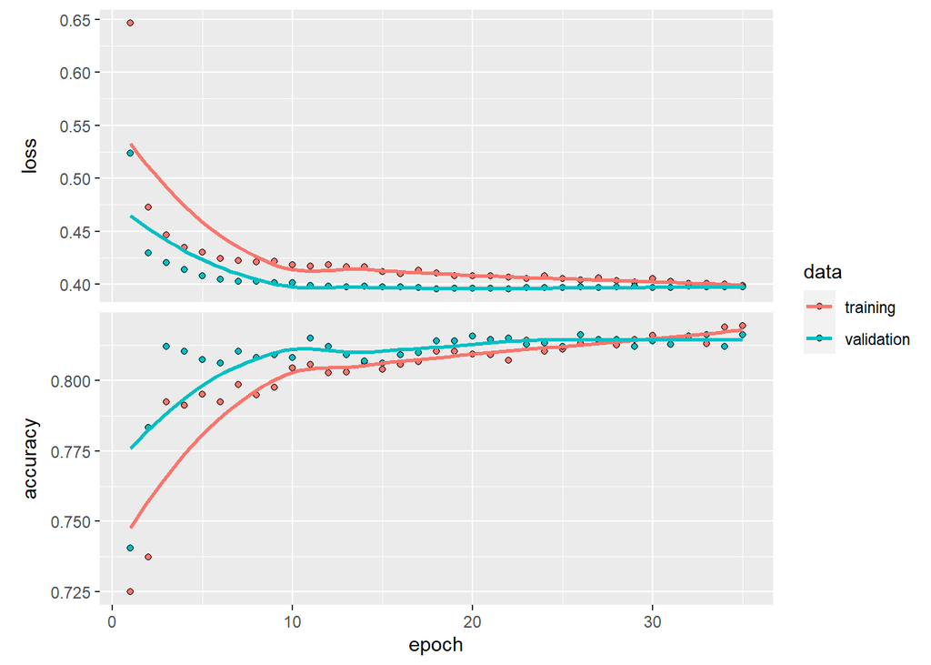

```r
# Plot the training/validation history of our Keras model
plot(history_6)
```

*Tip* Only use enough epochs to get a high validation accuracy. Once validation accuracy curve begins to flatten or decrease, it’s time to stop training.

let’s make some predictions from our keras model on the test data set, which was unseen during modeling. You can predict *class* or *probability*

```r
# Predicted Class
yhat_keras_class_vec_6 <- predict(object = model_keras_6, x = as.matrix(x_test_tbl_6)) %>% as.vector() %>% `>`(0.5)
# %>% k_cast("int32")


# Predicted Class Probability
yhat_keras_prob_vec_6  <- predict(object = model_keras_6, x = as.matrix(x_test_tbl_6)) %>%
    as.vector()
```

### Inspect Performance With Yardstick

```r
# Format test data and predictions for yardstick metrics
# estimates_keras_tbl <- tibble(
#   truth      = as.factor(y_test_vec) %>% fct_recode(yes = "1", no = "0"),
#   estimate   = as.factor(yhat_keras_class_vec) %>% fct_recode(yes = "1", no = "0"),
#   class_prob = yhat_keras_prob_vec
# )
estimates_keras_tbl_6 <- tibble(
  truth      = as.factor(y_test_vec_6) %>% fct_recode(yes = "1", no = "0"),
  estimate   = as.factor(yhat_keras_class_vec_6) %>% fct_recode(yes = "TRUE", no = "FALSE"),
  class_prob = yhat_keras_prob_vec_6
)
options(yardstick.event_first = FALSE) # the default is to classify 0 as the positive class instead of 1
estimates_keras_tbl_6
```

```
## # A tibble: 1,407 x 3
##    truth estimate class_prob
##    <fct> <fct>         <dbl>
##  1 yes   yes          0.830
##  2 no    no           0.455
##  3 no    no           0.0395
##  4 no    no           0.106
##  5 no    no           0.0211
##  6 yes   no           0.413
##  7 no    no           0.397
##  8 yes   yes          0.808
##  9 no    yes          0.521
## 10 no    no           0.143
## # ... with 1,397 more rows
```

### Confusion Table

```r
estimates_keras_tbl_6 %>% conf_mat(truth, estimate)
```

```
##           Truth
## Prediction  no yes
##        no  925 180
##        yes 109 193
```

### Accuracy

```r
acc_6 <- estimates_keras_tbl_6 %>% accuracy(truth, estimate)
```

### AUC

ROC Area Under the Curve (AUC) measurement

```r
roc_6 <- estimates_keras_tbl_6 %>% roc_auc(truth, class_prob)
```

### Precision and Recall

Precision is when the model predicts “yes”, how often is it actually “yes”. Recall (also true positive rate) is when the actual value is “yes” how often is the model correct

```r
prec_6 <- estimates_keras_tbl_6 %>% precision(truth, estimate)
rec_6 <- estimates_keras_tbl_6 %>% recall(truth, estimate)
```

### F1 Score

weighted average between the precision and recal

```r
fmeas_6 <- estimates_keras_tbl_6 %>% f_meas(truth, estimate)
```

```r
metrics_6 <- rbind(acc_6, roc_6, prec_6, rec_6, fmeas_6)
metrics_6 <- metrics_6 %>% select(c(1,3))
metrics_6 <- cbind(Model = c("Tuned ANN", "Tuned ANN", "Tuned ANN", "Tuned ANN", "Tuned ANN"), metrics_6)
metrics_6
```

```
##       Model   .metric .estimate
## 1 Tuned ANN  accuracy 0.7945984
## 2 Tuned ANN   roc_auc 0.8442836
## 3 Tuned ANN precision 0.6390728
## 4 Tuned ANN    recall 0.5174263
## 5 Tuned ANN    f_meas 0.5718519
```

# KNN Model

```r
train_tbl_4 <- train_tbl
#train_tbl_4$Churn[train_tbl_4$Churn == "Yes"] <- 1
#train_tbl_4$Churn[train_tbl_4$Churn == "No"] <- 0

test_tbl_4 <- test_tbl
#test_tbl_4$Churn[test_tbl_4$Churn == "Yes"] <- 1
#test_tbl_4$Churn[test_tbl_4$Churn == "No"] <- 0
```

```r
library(caret)
knn_fit <- train(Churn ~., data = train_tbl_4, method = "knn", trControl = trainControl("cv", classProbs = TRUE, summaryFunction = twoClassSummary, number = 10), preProcess = c("center", "scale"), metric = "ROC")
knn_fit
```

```
## k-Nearest Neighbors
##
## 5625 samples
##   19 predictor
##    2 classes: 'No', 'Yes'
##
## Pre-processing: centered (30), scaled (30)
## Resampling: Cross-Validated (10 fold)
## Summary of sample sizes: 5064, 5062, 5063, 5063, 5062, 5062, ...
## Resampling results across tuning parameters:
##
##   k  ROC        Sens       Spec
##   5  0.7749410  0.8459619  0.5153781
##   7  0.7924253  0.8498401  0.5320805
##   9  0.8015739  0.8568602  0.5400984
##
## ROC was used to select the optimal model using the largest value.
## The final value used for the model was k = 9.
```

```r
predictions_knn <- predict(knn_fit, test_tbl_4)

table(predictions_knn, test_tbl_4$Churn)
```

```
##
## predictions_knn  No Yes
##             No  883 171
##             Yes 151 202
```

```r
knn_roc <- as.data.frame(knn_fit$results[3,2])

knn_roc["Metric"] <- "roc_auc"

knn_roc <- knn_roc[, c(2,1)]

names(knn_roc)[names(knn_roc) == "knn_fit$results[3, 2]"] <- "Estimate"

knn_acc <- (table(predictions_knn, test_tbl_4$Churn)[1] + table(predictions_knn, test_tbl_4$Churn)[4]) /
     (table(predictions_knn, test_tbl_4$Churn)[1] + table(predictions_knn, test_tbl_4$Churn)[2] + table(predictions_knn, test_tbl_4$Churn)[3] + table(predictions_knn, test_tbl_4$Churn)[4])

knn_prec <- table(predictions_knn, test_tbl_4$Churn)[4]/(table(predictions_knn, test_tbl_4$Churn)[3] + table(predictions_knn, test_tbl_4$Churn)[4])

knn_rec <- table(predictions_knn, test_tbl_4$Churn)[4]/(table(predictions_knn, test_tbl_4$Churn)[2] + table(predictions_knn, test_tbl_4$Churn)[4])

knn_fmeas <- (2 * knn_prec * knn_rec)/(knn_prec + knn_rec)

metrics_knn <- as.data.frame(rbind(knn_acc, knn_prec, knn_rec, knn_fmeas))
metrics_knn <- cbind(Metric = rownames(metrics_knn), metrics_knn)
rownames(metrics_knn) <- 1:nrow(metrics_knn)
names(metrics_knn)[names(metrics_knn) == "V1"] <- "Estimate"
metrics_knn <- rbind(metrics_knn, knn_roc)
metrics_knn <- metrics_knn[c(1,5,2,3,4),]
metrics_knn$Metric[metrics_knn$Metric == "knn_acc"] <- "accuracy"
metrics_knn$Metric[metrics_knn$Metric == "knn_prec"] <- "precision"
metrics_knn$Metric[metrics_knn$Metric == "knn_rec"] <- "recall"
metrics_knn$Metric[metrics_knn$Metric == "knn_fmeas"] <- "f_meas"
metrics_knn <- cbind(Model = c("KNN", "KNN", "KNN", "KNN", "KNN"), metrics_knn)


metrics_knn
```

```
##   Model    Metric  Estimate
## 1   KNN  accuracy 0.7711443
## 5   KNN   roc_auc 0.8015739
## 2   KNN precision 0.5415550
## 3   KNN    recall 0.5722380
## 4   KNN    f_meas 0.5564738
```

```r
metrics_0 <- metrics_0 %>% select(c(1,3))
metrics_0 <- cbind(Model = c("Untuned ANN", "Untuned ANN", "Untuned ANN", "Untuned ANN", "Untuned ANN"), metrics_0)
metrics_0
```

```
##         Model   .metric .estimate
## 1 Untuned ANN  accuracy 0.7896233
## 2 Untuned ANN   roc_auc 0.8437456
## 3 Untuned ANN precision 0.6206897
## 4 Untuned ANN    recall 0.5308311
## 5 Untuned ANN    f_meas 0.5722543
```

```r
names(metrics_0)[names(metrics_0) == ".metric"] <- "Metric"
names(metrics_0)[names(metrics_0) == ".estimate"] <- "Estimate"

names(metrics_6)[names(metrics_6) == ".metric"] <- "Metric"
names(metrics_6)[names(metrics_6) == ".estimate"] <- "Estimate"

model_metrics_combined_2 <- rbind(metrics_0, metrics_6, metrics_knn)

model_metrics_combined_2 <- model_metrics_combined_2 %>%
                            add_row(Model = NA, Metric = NA, Estimate = NA, .before = 6) %>%
                            add_row(Model = NA, Metric = NA, Estimate = NA, .before = 12)

model_metrics_combined_2$Model[is.na(model_metrics_combined_2$Model)] <- "--"
model_metrics_combined_2$Metric[is.na(model_metrics_combined_2$Metric)] <- "--"
model_metrics_combined_2$Estimate[is.na(model_metrics_combined_2$Estimate)] <- "--"

model_metrics_combined_2
```

```
##             Model    Metric          Estimate
## 1     Untuned ANN  accuracy 0.789623312011372
## 2     Untuned ANN   roc_auc 0.843745624633766
## 3     Untuned ANN precision 0.620689655172414
## 4     Untuned ANN    recall  0.53083109919571
## 5     Untuned ANN    f_meas 0.572254335260116
## ...6           --        --                --
## 6       Tuned ANN  accuracy 0.794598436389481
## 7       Tuned ANN   roc_auc 0.844283632629991
## 8       Tuned ANN precision 0.639072847682119
## 9       Tuned ANN    recall 0.517426273458445
## 10      Tuned ANN    f_meas 0.571851851851852
## ...12          --        --                --
## 11            KNN  accuracy 0.771144278606965
## 51            KNN   roc_auc 0.801573905624595
## 21            KNN precision 0.541554959785523
## 31            KNN    recall 0.572237960339943
## 41            KNN    f_meas 0.556473829201102
```